# Exploratory Analysis of NHS Service Utilisation, Missed Appointments, and Social Media Insights

## 🗂️ Project Overview

This project explores patterns in service utilisation, missed appointments and turnaround times across the NHS network. The goal is to inform budgeting and infrastructure planning decisions by visualiusing usage, inefficiencies and public sentiment. We will also evaluate whether external data sources such as Twitter can provide actionable insights.

> Analyse patterns and trends in NHS service utilisation to inform effective resource allocation and budgeting decisions.

> Has there been adequate staffing and capacity in the networks?

> What was the actual utilisation of resources?

**Key focus areas:**

- What are the trends in service utilisation over time?
- Are missed appointments increasing or decreasing, and is this over a particular period?
- Do platforms such as Twitter (X) correlate with system-wide pressure points?

### 📊 NHS Service Utilisation Patterns

- Trends in context type and national category over time
- Comparison of number of appointment volume vs staffing capacity
- Analysis of booking-to-appointment turnaround time
- Evaluation of improved mapping for appointments

### ⛔ Missed Appointments

- Frequency and rate of missed appointments
- Temporal patterns: seasonality and commonly missed appointment types
- Investigation of whether longer turnaround times correlate with higher missed appointments

### 💬 Social Media Sentiment Analysis (Twitter)

- Trends in tweet volume and sentiment over time
- Spikes during notable NHS-related events such as COVID-19
- Exploration of correlations between sentiment, missed appointments, and turnaround times

## 📊 Data Overview

This project uses both internal NHS datasets and external social media data from Twitter to analyse service usage and public sentiment.

### 🔵 Internal NHS Data

- **actual_duration.csv:**
  - Appointment dates
  - Duration of each appointment
  - Number of appointments

📌 *Useful for analysing appointment length and capacity trends by location*

- **appointments_regional.csv:**
  - Appointment dates
  - Attendance status (attended, DNA, unknown)
  - Appointment mode (Face-to-Face, Home Visit, Telephone, Unknown, Video/Online)
  - Days between booking and appointment
  - Count of appointments

📌 *Enables analysis of appointment delivery methods and turnaround times.*

- **national_category.xlsx:**
  - Appointment dates
  - Service setting (GP, PCN etc)
  - Context type (clinical purpose)
  - National category (defined reasoning for appointment)
  - Count of appointments

📌 *Provides understanding of appointment purposes and how they may change over time.*

### 🟠 External NHS Data

- **tweets.csv:**
  - Full tweet texts
  - Number of favourites and retweets

📌 *Utilised to gauge public sentiment and engagement with healthcare topics.*

> The internal data provides operational insights, while external data offers context through public sentiment.

## 🧪 Data Validation & Summary Statistics

### 🧰 Prepare your workstation

```python
# Import the necessary libraries.
import pandas as pd
import numpy as np

# Ignore warnings.
import warnings
warnings.filterwarnings('ignore')
```

### 📥 Import The Datasets

```python
# Import the three datasets
ad = pd.read_csv('actual_duration.csv')
ar = pd.read_csv('appointments_regional.csv')
nc = pd.read_excel('national_categories.xlsx')
```

### 1️⃣ actual_duration.csv

```python
# View the actual_duration DataFrame
ad.head()
```

|  | sub_icb_location_code | sub_icb_location_ons_code | sub_icb_location_name | icb_ons_code | region_ons_code | appointment_date | actual_duration | count_of_appointments |
| --- | --- | --- | --- | --- | --- | --- | --- | --- |
| 0 | 00L | E38000130 | NHS North East and North Cumbria ICB - 00L | E54000050 | E40000012 | 01-Dec-21 | 31-60 Minutes | 364 |
| 1 | 00L | E38000130 | NHS North East and North Cumbria ICB - 00L | E54000050 | E40000012 | 01-Dec-21 | 21-30 Minutes | 619 |
| 2 | 00L | E38000130 | NHS North East and North Cumbria ICB - 00L | E54000050 | E40000012 | 01-Dec-21 | 6-10 Minutes | 1698 |
| 3 | 00L | E38000130 | NHS North East and North Cumbria ICB - 00L | E54000050 | E40000012 | 01-Dec-21 | Unknown / Data Quality | 1277 |
| 4 | 00L | E38000130 | NHS North East and North Cumbria ICB - 00L | E54000050 | E40000012 | 01-Dec-21 | 16-20 Minutes | 730 |

```python
# Check for missing values in ad
ad.isnull().sum()
```

```
sub_icb_location_code        0
sub_icb_location_ons_code    0
sub_icb_location_name        0
icb_ons_code                 0
region_ons_code              0
appointment_date             0
actual_duration              0
count_of_appointments        0
dtype: int64
```

*There are no missing values in the actual_duration DataFrame*

```python
# Determine the metadata of the data set.
ad.info()
```

```
<class 'pandas.core.frame.DataFrame'>
RangeIndex: 137793 entries, 0 to 137792
Data columns (total 8 columns):
 #   Column                     Non-Null Count   Dtype
---  ------                     --------------   -----
 0   sub_icb_location_code      137793 non-null  object
 1   sub_icb_location_ons_code  137793 non-null  object
 2   sub_icb_location_name      137793 non-null  object
 3   icb_ons_code               137793 non-null  object
 4   region_ons_code            137793 non-null  object
 5   appointment_date           137793 non-null  object
 6   actual_duration            137793 non-null  object
 7   count_of_appointments      137793 non-null  int64
dtypes: int64(1), object(7)
memory usage: 8.4+ MB
```

```python
# Determine the descriptive statistics of the data set.
ad.describe()
```

|  | count_of_appointments |
| --- | --- |
| count | 137793.000000 |
| mean | 1219.080011 |
| std | 1546.902956 |
| min | 1.000000 |
| 25% | 194.000000 |
| 50% | 696.000000 |
| 75% | 1621.000000 |
| max | 15400.000000 |

### 2️⃣ appointments_regional.csv

```python
# View the DataFrame.
ar.head()
```

|  | icb_ons_code | appointment_month | appointment_status | hcp_type | appointment_mode | time_between_book_and_appointment | count_of_appointments |
| --- | --- | --- | --- | --- | --- | --- | --- |
| 0 | E54000034 | 2020-01 | Attended | GP | Face-to-Face | 1 Day | 8107 |
| 1 | E54000034 | 2020-01 | Attended | GP | Face-to-Face | 15 to 21 Days | 6791 |
| 2 | E54000034 | 2020-01 | Attended | GP | Face-to-Face | 2 to 7 Days | 20686 |
| 3 | E54000034 | 2020-01 | Attended | GP | Face-to-Face | 22 to 28 Days | 4268 |
| 4 | E54000034 | 2020-01 | Attended | GP | Face-to-Face | 8 to 14 Days | 11971 |

```python
# Check for missing values in ar
ar.isnull().sum()
```

```
icb_ons_code                         0
appointment_month                    0
appointment_status                   0
hcp_type                             0
appointment_mode                     0
time_between_book_and_appointment    0
count_of_appointments                0
dtype: int64
```

*There are no missing values in the appointments_regional DataFrame*

```python
# Determine the metadata of the data set.
ar.info()
```

```
<class 'pandas.core.frame.DataFrame'>
RangeIndex: 596821 entries, 0 to 596820
Data columns (total 7 columns):
 #   Column                             Non-Null Count   Dtype
---  ------                             --------------   -----
 0   icb_ons_code                       596821 non-null  object
 1   appointment_month                  596821 non-null  object
 2   appointment_status                 596821 non-null  object
 3   hcp_type                           596821 non-null  object
 4   appointment_mode                   596821 non-null  object
 5   time_between_book_and_appointment  596821 non-null  object
 6   count_of_appointments              596821 non-null  int64
dtypes: int64(1), object(6)
memory usage: 31.9+ MB
```

```python
# Determine the descriptive statistics of the data set.
ar.describe()
```

|  | count_of_appointments |
| --- | --- |
| count | 596821.000000 |
| mean | 1244.601857 |
| std | 5856.887042 |
| min | 1.000000 |
| 25% | 7.000000 |
| 50% | 47.000000 |
| 75% | 308.000000 |
| max | 211265.000000 |

### 3️⃣ national_categories.xlsx

```python
# View the DataFrame.
nc.head()
```

|  | appointment_date | icb_ons_code | sub_icb_location_name | service_setting | context_type | national_category | count_of_appointments | appointment_month |
| --- | --- | --- | --- | --- | --- | --- | --- | --- |
| 0 | 2021-08-02 | E54000050 | NHS North East and North Cumbria ICB - 00L | Primary Care Network | Care Related Encounter | Patient contact during Care Home Round | 3 | 2021-08 |
| 1 | 2021-08-02 | E54000050 | NHS North East and North Cumbria ICB - 00L | Other | Care Related Encounter | Planned Clinics | 7 | 2021-08 |
| 2 | 2021-08-02 | E54000050 | NHS North East and North Cumbria ICB - 00L | General Practice | Care Related Encounter | Home Visit | 79 | 2021-08 |
| 3 | 2021-08-02 | E54000050 | NHS North East and North Cumbria ICB - 00L | General Practice | Care Related Encounter | General Consultation Acute | 725 | 2021-08 |
| 4 | 2021-08-02 | E54000050 | NHS North East and North Cumbria ICB - 00L | General Practice | Care Related Encounter | Structured Medication Review | 2 | 2021-08 |

```python
# Check for missing values in nc
nc.isnull().sum()
```

```
appointment_date         0
icb_ons_code             0
sub_icb_location_name    0
service_setting          0
context_type             0
national_category        0
count_of_appointments    0
appointment_month        0
dtype: int64
```

*There are no missing values in the national_categories DataFrame*

```python
# Determine the metadata of the data set.
nc.info()
```

```
<class 'pandas.core.frame.DataFrame'>
RangeIndex: 817394 entries, 0 to 817393
Data columns (total 8 columns):
 #   Column                 Non-Null Count   Dtype
---  ------                 --------------   -----
 0   appointment_date       817394 non-null  datetime64[ns]
 1   icb_ons_code           817394 non-null  object
 2   sub_icb_location_name  817394 non-null  object
 3   service_setting        817394 non-null  object
 4   context_type           817394 non-null  object
 5   national_category      817394 non-null  object
 6   count_of_appointments  817394 non-null  int64
 7   appointment_month      817394 non-null  object
dtypes: datetime64[ns](1), int64(1), object(6)
memory usage: 49.9+ MB
```

```python
# Determine the descriptive statistics of the data set.
nc.describe()
```

|  | appointment_date | count_of_appointments |
| --- | --- | --- |
| count | 817394 | 817394.000000 |
| mean | 2022-01-16 00:50:35.860796160 | 362.183684 |
| min | 2021-08-01 00:00:00 | 1.000000 |
| 25% | 2021-10-25 00:00:00 | 7.000000 |
| 50% | 2022-01-18 00:00:00 | 25.000000 |
| 75% | 2022-04-07 00:00:00 | 128.000000 |
| max | 2022-06-30 00:00:00 | 16590.000000 |
| std | NaN | 1084.576600 |

## 🔍 Exploratory Data Analysis

### ❓ How many locations are there in the data set?

```python
# Determine the number of locations.
num_unique_locations = nc['sub_icb_location_name'].nunique()
print(f"There are {num_unique_locations} unique locations in our dataset.")
```

```
There are 106 unique locations in our dataset.
```

### ❓ What are the five locations with the highest number of appointments?

```python
# Determine the top five locations based on record count.
top_5_locations = (
    nc.groupby('sub_icb_location_name')['count_of_appointments']
    .sum()
    .sort_values(ascending = False)
    .head(5)
)

print(top_5_locations)
```

```
sub_icb_location_name
NHS North West London ICB - W2U3Z              12142390
NHS North East London ICB - A3A8R               9588891
NHS Kent and Medway ICB - 91Q                   9286167
NHS Hampshire and Isle Of Wight ICB - D9Y0V     8288102
NHS South East London ICB - 72Q                 7850170
Name: count_of_appointments, dtype: int64
```

### ❓ How many service settings, context types, national categories, and appointment statuses are there?

#### ⬤ Service Settings

```python
# Determine the number of service settings.
num_service_settings = nc['service_setting'].unique()

# Print the list
print("List of unique service settings:")
for setting in num_service_settings:
    print("-", setting)

# Print the total number
print(f"\nTotal number of unique service settings: {len(num_service_settings)}")
```

```
List of unique service settings:
- Primary Care Network
- Other
- General Practice
- Unmapped
- Extended Access Provision

Total number of unique service settings: 5
```

#### ⬤ Context Types

```python
# Determine the number of context types.
num_context_types = nc['context_type'].unique()

# Print the list
print("List of unique context types:")
for context in num_context_types:
    print("-", context)

print(f"\nTotal number of unique context types: {len(num_context_types)}")
```

```
List of unique context types:
- Care Related Encounter
- Unmapped
- Inconsistent Mapping

Total number of unique context types: 3
```

#### ⬤ National Categories

```python
# Determine the number of national categories.
num_national_categories = nc['national_category'].unique()

# Print the list
print("List of unique national categories:")
for category in num_national_categories:
    print("-", category)

print(f"\nTotal number of unique national categories: {len(num_national_categories)}")
```

```
List of unique national categories:
- Patient contact during Care Home Round
- Planned Clinics
- Home Visit
- General Consultation Acute
- Structured Medication Review
- Care Home Visit
- Unmapped
- Clinical Triage
- Planned Clinical Procedure
- Inconsistent Mapping
- Care Home Needs Assessment & Personalised Care and Support Planning
- General Consultation Routine
- Service provided by organisation external to the practice
- Unplanned Clinical Activity
- Social Prescribing Service
- Non-contractual chargeable work
- Group Consultation and Group Education
- Walk-in

Total number of unique national categories: 18
```

#### ⬤ Appointment Statuses

```python
# Determine the number of appointment statuses.
num_appointment_status = ar['appointment_status'].unique()

# Print the list
print('List of unique appointment statuses')
for appointment in num_appointment_status:
    print ("-", appointment)

print(f"\nTotal number of unique appointment statuses: {len(num_appointment_status)}")
```

```
List of unique appointment statuses
- Attended
- DNA
- Unknown

Total number of unique appointment statuses: 3
```

### ❓ Between what dates were appointments scheduled?

#### ⬤ View the three DataFrames to determine the date format

```python
# View the first five rows of appointment_date for the ad DataFrame to determine the date format.
ad.head()
```

|  | sub_icb_location_code | sub_icb_location_ons_code | sub_icb_location_name | icb_ons_code | region_ons_code | appointment_date | actual_duration | count_of_appointments |
| --- | --- | --- | --- | --- | --- | --- | --- | --- |
| 0 | 00L | E38000130 | NHS North East and North Cumbria ICB - 00L | E54000050 | E40000012 | 01-Dec-21 | 31-60 Minutes | 364 |
| 1 | 00L | E38000130 | NHS North East and North Cumbria ICB - 00L | E54000050 | E40000012 | 01-Dec-21 | 21-30 Minutes | 619 |
| 2 | 00L | E38000130 | NHS North East and North Cumbria ICB - 00L | E54000050 | E40000012 | 01-Dec-21 | 6-10 Minutes | 1698 |
| 3 | 00L | E38000130 | NHS North East and North Cumbria ICB - 00L | E54000050 | E40000012 | 01-Dec-21 | Unknown / Data Quality | 1277 |
| 4 | 00L | E38000130 | NHS North East and North Cumbria ICB - 00L | E54000050 | E40000012 | 01-Dec-21 | 16-20 Minutes | 730 |

```python
# View the first five rows of the appointment_date for the ar DataFrame and determine the date format.
ar.head()
```

|  | icb_ons_code | appointment_month | appointment_status | hcp_type | appointment_mode | time_between_book_and_appointment | count_of_appointments |
| --- | --- | --- | --- | --- | --- | --- | --- |
| 0 | E54000034 | 2020-01 | Attended | GP | Face-to-Face | 1 Day | 8107 |
| 1 | E54000034 | 2020-01 | Attended | GP | Face-to-Face | 15 to 21 Days | 6791 |
| 2 | E54000034 | 2020-01 | Attended | GP | Face-to-Face | 2 to 7 Days | 20686 |
| 3 | E54000034 | 2020-01 | Attended | GP | Face-to-Face | 22 to 28 Days | 4268 |
| 4 | E54000034 | 2020-01 | Attended | GP | Face-to-Face | 8 to 14 Days | 11971 |

```python
# View the first five rows of the appointmnt_date for the nc DataFrame and determine the date format.
nc.head()
```

|  | appointment_date | icb_ons_code | sub_icb_location_name | service_setting | context_type | national_category | count_of_appointments | appointment_month |
| --- | --- | --- | --- | --- | --- | --- | --- | --- |
| 0 | 2021-08-02 | E54000050 | NHS North East and North Cumbria ICB - 00L | Primary Care Network | Care Related Encounter | Patient contact during Care Home Round | 3 | 2021-08 |
| 1 | 2021-08-02 | E54000050 | NHS North East and North Cumbria ICB - 00L | Other | Care Related Encounter | Planned Clinics | 7 | 2021-08 |
| 2 | 2021-08-02 | E54000050 | NHS North East and North Cumbria ICB - 00L | General Practice | Care Related Encounter | Home Visit | 79 | 2021-08 |
| 3 | 2021-08-02 | E54000050 | NHS North East and North Cumbria ICB - 00L | General Practice | Care Related Encounter | General Consultation Acute | 725 | 2021-08 |
| 4 | 2021-08-02 | E54000050 | NHS North East and North Cumbria ICB - 00L | General Practice | Care Related Encounter | Structured Medication Review | 2 | 2021-08 |

#### ⬤ Change the date format of the three datasets

```python
ad['appointment_date'] = pd.to_datetime(ad['appointment_date'], dayfirst = True)
ar['appointment_month'] = pd.to_datetime(ar['appointment_month'], format='%Y-%m').dt.to_period('M')
nc['appointment_date'] = pd.to_datetime(nc['appointment_date'], dayfirst = True)
```

#### ⬤ Create variables to show the minimum and maximum date for each DataFrame

```python
# Actual Duration (ad)
ad_min_date = ad['appointment_date'].min()
ad_max_date = ad['appointment_date'].max()

# Appointments Regional (ar)
ar_min_date = ar['appointment_month'].min()
ar_max_date = ar['appointment_month'].max()

# National Categories (nc)
nc_min_date = nc['appointment_date'].min()
nc_max_date = nc['appointment_date'].max()
```

#### ⬤ Print the results showing the minimum and maximum date for each DataFrame

```python
print(f"In the 'ad' DataFrame, the earliest date is {ad_min_date.date()}, and the latest date is {ad_max_date.date()}.")
print(f"In the 'ar' DataFrame, the earliest date is {ar_min_date.strftime('%Y-%m')}, and the latest date is {ar_max_date.strftime('%Y-%m')}.")
print(f"In the 'nc' DataFrame, the earliest date is {nc_min_date.date()}, and the latest date is {nc_max_date.date()}.")
```

```
In the 'ad' DataFrame, the earliest date is 2021-12-01, and the latest date is 2022-06-30.
In the 'ar' DataFrame, the earliest date is 2020-01, and the latest date is 2022-06.
In the 'nc' DataFrame, the earliest date is 2021-08-01, and the latest date is 2022-06-30.
```

### ❓ Which service setting was the most popular for NHS North West London from 1 January to 1 June 2022?

```python
# Create a variable presenting only rows with 'W2U3Z' in its 'sub_icb_location_name
nc_subset = nc[nc['sub_icb_location_name'].str.contains('W2U3Z', na = False)]

# Ensure 'appointment_date is datetime format
nc_subset['appointment_date'] = pd.to_datetime(nc_subset['appointment_date'], errors = 'coerce')

# Filter by date range: 1 Jan 2022 to 1 Jun 2022
start_date = '2022-01-01'
end_date = '2022-06-01'
nc_subset = nc_subset[
    (nc_subset['appointment_date'] >= start_date) &
    (nc_subset['appointment_date'] <= end_date)
]

# Count appointments by service setting
service_counts = (
    nc_subset.groupby('service_setting')['count_of_appointments']
    .sum()
    .sort_values(ascending = False)
)

# View the output.
print("Total appointments by service setting (descending):")
print(service_counts)

# Write a sentence showing the most common service.
most_common_service = service_counts.idxmax()
most_common_count = service_counts.max()
print(f"\nThe service setting with the most appointments is: {most_common_service} ({most_common_count} appointments)")
```

```
Total appointments by service setting (descending):
service_setting
General Practice             4804239
Unmapped                      391106
Other                         152897
Primary Care Network          109840
Extended Access Provision      98159
Name: count_of_appointments, dtype: int64

The service setting with the most appointments is: General Practice (4804239 appointments)
```

### ❓ Which month had the highest number of appointments?

```python
# Group by year and month, then sum the appointment counts
monthly_counts = (
    nc.groupby([nc['appointment_date'].dt.year.rename('year'),
                nc['appointment_date'].dt.month.rename('month')])
               ['count_of_appointments']
    .sum()
    .sort_values(ascending = False)
)

# Show the results
print("Total appointments per month:")
print(monthly_counts.head())

# Create a sentence that shows the month with the highest appointments
top_month = monthly_counts.idxmax()
top_count = monthly_counts.max()
print(f"\nThe month with the highest number of appointments is: {top_month}, with a total of {top_count}.")
```

```
Total appointments per month:
year  month
2021  11       30405070
      10       30303834
2022  3        29595038
2021  9        28522501
2022  5        27495508
Name: count_of_appointments, dtype: int64

The month with the highest number of appointments is: (2021, 11), with a total of 30405070.
```

### ❓ What was the total number of records per month?

```python
# Total number of records per month (nc DataFrame)
records_per_month_nc = (
    nc['appointment_date']
    .dt.to_period('M')
    .value_counts()
    .sort_index()
)

print("Total number of records per month (nc DataFrame):")
print(records_per_month_nc)
```

```
Total number of records per month (nc DataFrame):
appointment_date
2021-08    69999
2021-09    74922
2021-10    74078
2021-11    77652
2021-12    72651
2022-01    71896
2022-02    71769
2022-03    82822
2022-04    70012
2022-05    77425
2022-06    74168
Freq: M, Name: count, dtype: int64
```

```python
# Total number of records per month (ar DataFrame)
records_per_month_ar = (
    ar['appointment_month']
    .value_counts()
    .sort_index()
)

print("Total number of records per month (ar DataFrame):")
print(records_per_month_ar)
```

```
Total number of records per month (ar DataFrame):
appointment_month
2020-01    20889
2020-02    20689
2020-03    21350
2020-04    19124
2020-05    18338
2020-06    18844
2020-07    19502
2020-08    19247
2020-09    20043
2020-10    20122
2020-11    19675
2020-12    19394
2021-01    19319
2021-02    18949
2021-03    19369
2021-04    19452
2021-05    19384
2021-06    19814
2021-07    19899
2021-08    19786
2021-09    20441
2021-10    20562
2021-11    20766
2021-12    20393
2022-01    20225
2022-02    20133
2022-03    20532
2022-04    20073
2022-05    20276
2022-06    20231
Freq: M, Name: count, dtype: int64
```

```python
# Total number of records per month (ad DataFrame)
records_per_month_ad = (
    ad['appointment_date']
    .dt.to_period('M')
    .value_counts()
    .sort_index()
)

print("Total number of records per month (ad Dataframe):")
print(records_per_month_ad)
```

```
Total number of records per month (ad Dataframe):
appointment_date
2021-12    19507
2022-01    19643
2022-02    18974
2022-03    21236
2022-04    19078
2022-05    20128
2022-06    19227
Freq: M, Name: count, dtype: int64
```

## 📊 Visualisation of NHS Data

This section presents a series of visual analyses aimed at identifying patterns, trends and insights from the cleaned internal NHS data.

This includes interpreting of data, support hypotheses, and identify areas of interest for further investigation.

### 🧰 Import the necessary libraries for visualisations

```python
# Import the necessary libraries.
import seaborn as sns
import matplotlib.pyplot as plt

# Set figure size.
sns.set(rc={'figure.figsize':(15, 12)})

# Set the plot style as white.
sns.set_style('white')
```

**Change the data type of appointment month to string for ease of visualisation**

```python
# Change the data type of the appointment month to string to allow for easier plotting.
nc['appointment_month'] = nc['appointment_month'].astype(str)
```

### 📈 Monthly Appointments by Service Setting

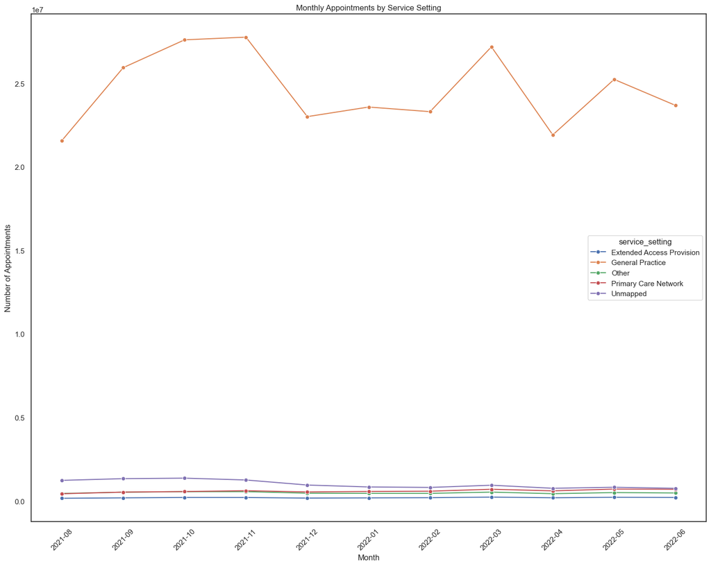

```python
# Aggregate the DataFrame to group the monthly appointments and service settings
nc_ss = (
    nc.groupby(['appointment_month','service_setting'])['count_of_appointments']
    .sum()
    .reset_index()
    .sort_values(by = 'appointment_month')
)

# Use the nc_ss DataFrame to create a lineplot
sns.lineplot(
    data = nc_ss,
    x = 'appointment_month',
    y = 'count_of_appointments',
    hue = 'service_setting',
    marker = 'o'
)

# Format and label the graph
plt.xticks(rotation = 45)
plt.title('Monthly Appointments by Service Setting')
plt.xlabel('Month')
plt.ylabel('Number of Appointments')
plt.tight_layout()
plt.show()
```

### 📈 Monthly Appointments by Context Type

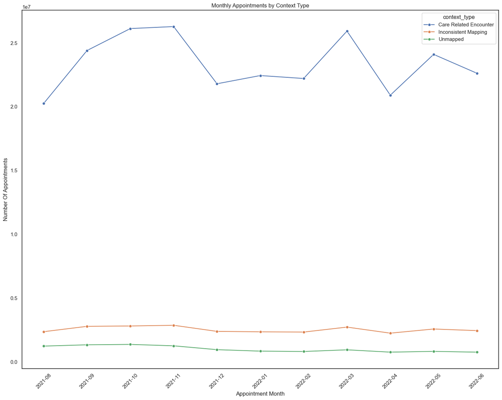

```python
# Aggregate the DataFrame to group the monthly appointments and context types.
nc_ct = (
    nc.groupby(['appointment_month','context_type'])['count_of_appointments']
    .sum()
    .reset_index()
    .sort_values(by = 'appointment_month')
)

# Use the nc_ct DataFrame to create a lineplot
sns.lineplot(
    data = nc_ct,
    x = 'appointment_month',
    y = 'count_of_appointments',
    hue = 'context_type',
    marker = 'o'
)

# Format and label the graph
plt.title('Monthly Appointments by Context Type')
plt.xlabel('Appointment Month')
plt.ylabel('Number Of Appointments')
plt.xticks(rotation = 45)
plt.tight_layout()
plt.show()
```

### 📈 Monthly Appointments by National Category

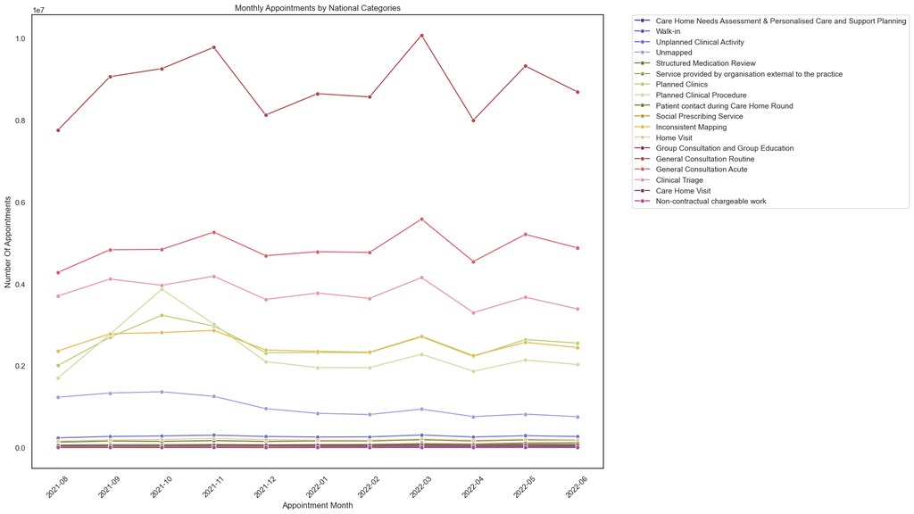

```python
# Aggregate the DataFrame to group the monthly appointments and national categories
nc_nc = (
    nc.groupby(['appointment_month','national_category'])['count_of_appointments']
    .sum()
    .reset_index()
    .sort_values(by = 'appointment_month')
)

# Create a lineplot using the nc_nc DataFrame
sns.lineplot(
    data = nc_nc,
    x = 'appointment_month',
    y = 'count_of_appointments',
    hue = 'national_category',
    marker = 'o',
    palette='tab20b'
)

# Format and label the graph
plt.title('Monthly Appointments by National Categories')
plt.xlabel('Appointment Month')
plt.ylabel('Number Of Appointments')
plt.xticks(rotation = 45)
plt.legend(bbox_to_anchor=(1.05, 1), loc='upper left', borderaxespad=0.)
plt.show()
```

### 📈 Total Appointments For Each Service Setting Per Season

#### Create variables for each season displaying the service setting and the total appointments for each.

```python
# Summer season
nc_summer = nc[
    (nc['appointment_month'] >= '2021-06') &
    (nc['appointment_month'] <= '2021-08')
]

nc_summer_appts = (
    nc_summer
    .groupby('service_setting')['count_of_appointments']
    .sum()
    .reset_index()
)

# Autumn season
nc_autumn = nc[
    (nc['appointment_month'] >= '2021-09') &
    (nc['appointment_month'] <= '2021-11')
]

nc_autumn_appts = (
    nc_autumn
    .groupby('service_setting')['count_of_appointments']
    .sum()
    .reset_index()
)

# Winter season
nc_winter = nc[
    (nc['appointment_month'] >= '2021-12') &
    (nc['appointment_month'] <= '2022-02')
]

nc_winter_appts = (
    nc_winter
    .groupby('service_setting')['count_of_appointments']
    .sum()
    .reset_index()
)

# Spring season
nc_spring = nc[
    (nc['appointment_month'] >= '2022-03') &
    (nc['appointment_month'] >= '2022-05')
]

nc_spring_appts = (
    nc_spring
    .groupby('service_setting')['count_of_appointments']
    .sum()
    .reset_index()
)
```

#### Create a visualisation displaying data for all seasons

```python
# Add a 'Season' column to each DataFrame
nc_summer_appts['Season'] = 'Summer'
nc_autumn_appts['Season'] = 'Autumn'
nc_winter_appts['Season'] = 'Winter'
nc_spring_appts['Season'] = 'Spring'

# Combine all the DataFrames into one
all_seasons_df = pd.concat([
    nc_summer_appts,
    nc_autumn_appts,
    nc_winter_appts,
    nc_spring_appts
])
```

```python
all_seasons_df.head(10)
```

|  | service_setting | count_of_appointments | Season |
| --- | --- | --- | --- |
| 0 | Extended Access Provision | 160927 | Summer |
| 1 | General Practice | 21575852 | Summer |
| 2 | Other | 449101 | Summer |
| 3 | Primary Care Network | 432448 | Summer |
| 4 | Unmapped | 1233843 | Summer |
| 0 | Extended Access Provision | 605022 | Autumn |
| 1 | General Practice | 81314881 | Autumn |
| 2 | Other | 1642445 | Autumn |
| 3 | Primary Care Network | 1709790 | Autumn |
| 4 | Unmapped | 3959267 | Autumn |

[figure not shown]

```python
# Create a lineplot to display this data
sns.lineplot(
    data = all_seasons_df,
    x = 'service_setting',
    y = 'count_of_appointments',
    hue = 'Season',
    hue_order = ['Autumn','Winter','Spring','Summer']
)

# Format and label the lineplot
plt.title('Appointments Across Seasons (Jun 2021 to May 2022)')
plt.xlabel('Service Setting')
plt.ylabel('Number of Appointments')
plt.legend(title='Appointment Status', fontsize=16, title_fontsize=18)
plt.show()
```

## 📊 Analysis of tweets with hashtags related to healthcare in the UK

### 📥 Import the dataset and set the conditions for our visualisations

```python
# Import relevant libraries
import re

# Set figure size.
sns.set(rc={'figure.figsize':(15, 12)})

# Set the plot style as white.
sns.set_style('white')

# Maximum column width to display
pd.options.display.max_colwidth = 200

# Import the 'tweets.csv' dataset
td = pd.read_csv('tweets.csv')

# View the DataFrame
td.head()
```

|  | tweet_id | tweet_full_text | tweet_entities | tweet_entities_hashtags | tweet_metadata | tweet_retweet_count | tweet_favorite_count | tweet_favorited | tweet_retweeted | tweet_lang |
| --- | --- | --- | --- | --- | --- | --- | --- | --- | --- | --- |
| 0 | 1567629223795527681 | As Arkansas’ first Comprehensive Stroke Certified Center, UAMS provides Arkansans with access to the most advanced stoke care. Join us in our mission to make a difference in the health and well-be... | {'hashtags': [{'text': 'Healthcare', 'indices': [253, 264]}], 'symbols': [], 'user_mentions': [], 'urls': [{'url': 'https://t.co/yw0cstfmSI', 'expanded_url': 'https://bit.ly/3BiSKbs', 'display_url... | #Healthcare | {'iso_language_code': 'en', 'result_type': 'recent'} | 0 | 0 | False | False | en |
| 1 | 1567582846612553728 | RT @AndreaGrammer: Work-life balance is at the foundation of how decisions are made and where #PremiseHealth is headed. We're #hiring for… | {'hashtags': [{'text': 'PremiseHealth', 'indices': [94, 108]}, {'text': 'hiring', 'indices': [127, 134]}], 'symbols': [], 'user_mentions': [{'screen_name': 'AndreaGrammer', 'name': 'Andrea Grammer... | #PremiseHealth, #hiring | {'iso_language_code': 'en', 'result_type': 'recent'} | 2 | 0 | False | False | en |
| 2 | 1567582787070304256 | RT @OntarioGreens: $10 billion can go a long way to fixing our broken #Healthcare system.\n\nYet Doug Ford would rather spend it ALL on a hig… | {'hashtags': [{'text': 'Healthcare', 'indices': [70, 81]}], 'symbols': [], 'user_mentions': [{'screen_name': 'OntarioGreens', 'name': 'Green Party of Ontario', 'id': 37115912, 'id_str': '37115912'... | #Healthcare | {'iso_language_code': 'en', 'result_type': 'recent'} | 39 | 0 | False | False | en |
| 3 | 1567582767625428992 | RT @modrnhealthcr: 🚨#NEW:🚨 Insurance companies are figuring out the best ways to collect information about members’ race and ethnicity data… | {'hashtags': [{'text': 'NEW', 'indices': [20, 24]}], 'symbols': [], 'user_mentions': [{'screen_name': 'modrnhealthcr', 'name': 'Modern Healthcare', 'id': 18935711, 'id_str': '18935711', 'indices':... | #NEW | {'iso_language_code': 'en', 'result_type': 'recent'} | 5 | 0 | False | False | en |
| 4 | 1567582720460570625 | ICYMI: Our recent blogs on Cybersecurity in Accounting https://t.co/4nnK0FiVVL and Digital Transformation in Healthcare Finance https://t.co/jIqn52lHD3 are a great read, take a look!\n\n#blogs #di... | {'hashtags': [{'text': 'blogs', 'indices': [184, 190]}, {'text': 'digitaltransformation', 'indices': [191, 213]}, {'text': 'cybersecurity', 'indices': [214, 228]}, {'text': 'accounting', 'indices'... | #blogs, #digitaltransformation, #cybersecurity, #accounting, #finance, #healthcare | {'iso_language_code': 'en', 'result_type': 'recent'} | 0 | 0 | False | False | en |

```python
# Explore the metadata.
td.info()
```

```
<class 'pandas.core.frame.DataFrame'>
RangeIndex: 1174 entries, 0 to 1173
Data columns (total 10 columns):
 #   Column                   Non-Null Count  Dtype
---  ------                   --------------  -----
 0   tweet_id                 1174 non-null   int64
 1   tweet_full_text          1174 non-null   object
 2   tweet_entities           1174 non-null   object
 3   tweet_entities_hashtags  1007 non-null   object
 4   tweet_metadata           1174 non-null   object
 5   tweet_retweet_count      1174 non-null   int64
 6   tweet_favorite_count     1174 non-null   int64
 7   tweet_favorited          1174 non-null   bool
 8   tweet_retweeted          1174 non-null   bool
 9   tweet_lang               1174 non-null   object
dtypes: bool(2), int64(3), object(5)
memory usage: 75.8+ KB
```

```python
# Explore the data set.
td.describe()
```

|  | tweet_id | tweet_retweet_count | tweet_favorite_count |
| --- | --- | --- | --- |
| count | 1.174000e+03 | 1174.000000 | 1174.00000 |
| mean | 1.567612e+18 | 8.629472 | 0.37138 |
| std | 2.427553e+13 | 29.784675 | 2.04470 |
| min | 1.567574e+18 | 0.000000 | 0.00000 |
| 25% | 1.567590e+18 | 0.000000 | 0.00000 |
| 50% | 1.567611e+18 | 1.000000 | 0.00000 |
| 75% | 1.567633e+18 | 3.000000 | 0.00000 |
| max | 1.567655e+18 | 303.000000 | 42.00000 |

### 🔍 Exploring the analytical value of retweeted and favourited tweets

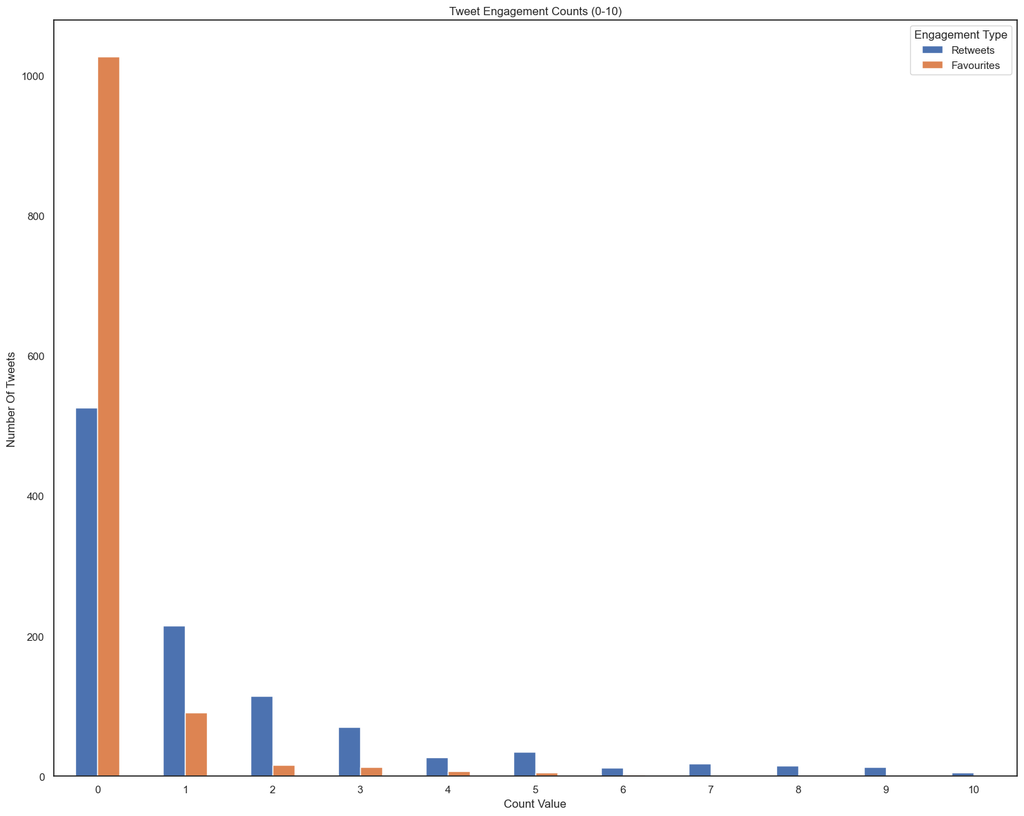

|  | Retweets | Favourites |
| --- | --- | --- |
| 0 | 526 | 1027 |
| 1 | 215 | 91 |
| 2 | 114 | 16 |
| 3 | 70 | 13 |
| 4 | 27 | 7 |
| 5 | 35 | 5 |
| 6 | 12 | 2 |
| 7 | 18 | 1 |
| 8 | 15 | 1 |
| 9 | 13 | 1 |
| 10 | 5 | 1 |

```python
# Create variables for 'retweet_count' and 'favorite_count'
retweet_counts = td['tweet_retweet_count'].value_counts().sort_index()
favorite_counts = td['tweet_favorite_count'].value_counts().sort_index()

# Limit to a reasonable count range
max_count = 10

# Reindex to ensure all counts from 0 to max_count are present
index = range(0, max_count + 1)
retweet_counts = retweet_counts.reindex(index, fill_value = 0)
favorite_counts = favorite_counts.reindex(index, fill_value = 0)

# Combine into one data frame
rf_combined = pd.DataFrame({
    'Retweets': retweet_counts,
    'Favourites': favorite_counts
}, index = index)

# Plot side-by-side bars
rf_combined.plot(kind = 'bar')
plt.title('Tweet Engagement Counts (0-10)')
plt.xlabel('Count Value')
plt.ylabel('Number Of Tweets')
plt.xticks(rotation = 0)
plt.legend(title = 'Engagement Type')
plt.tight_layout()
plt.show()

rf_combined
```

**Is filtering by engagement thresholds valuable?**

The distribution suggests that most healthcare-related tweets did not capture significant public attention. The small subset of tweets which did receive public attention may be valuable for further analysis.

Filtering tweets based on engagement thresholds (>= 5 retweets/favourites) can indicate patterns in more widely circulated content. In addition, zero engagement tweets may alo be spam or bots, which negatively impacts qualitative analysis. However, filtering out tweets based on engagement may result in a loss of overall context as engagement does not necessarily equate to importance.

### 📊 Determining the most popular tweets

```python
# Create a new DataFrame containing only the text.
tweets_text = td[['tweet_full_text']].copy()

# View the DataFrame.
tweets_text.head()
```

|  | tweet_full_text |
| --- | --- |
| 0 | As Arkansas’ first Comprehensive Stroke Certified Center, UAMS provides Arkansans with access to the most advanced stoke care. Join us in our mission to make a difference in the health and well-be... |
| 1 | RT @AndreaGrammer: Work-life balance is at the foundation of how decisions are made and where #PremiseHealth is headed. We're #hiring for… |
| 2 | RT @OntarioGreens: $10 billion can go a long way to fixing our broken #Healthcare system.\n\nYet Doug Ford would rather spend it ALL on a hig… |
| 3 | RT @modrnhealthcr: 🚨#NEW:🚨 Insurance companies are figuring out the best ways to collect information about members’ race and ethnicity data… |
| 4 | ICYMI: Our recent blogs on Cybersecurity in Accounting https://t.co/4nnK0FiVVL and Digital Transformation in Healthcare Finance https://t.co/jIqn52lHD3 are a great read, take a look!\n\n#blogs #di... |

```python
# Loop through the messages, and create a list of values containing the # symbol.
tags = []

for y in [x.split(' ') for x in td['tweet_full_text'].dropna().values]:
    for z in y:
        if '#' in z:
            match = re.search(r'#\w+', z.lower())
            if match:
                tags.append(match.group())


tags = pd.Series(tags).value_counts()
```

```python
# Display the first 30 records.
tags.head(30)
```

```
#healthcare                 837
#health                      88
#ai                          47
#medicine                    42
#job                         38
#medical                     35
#digitalhealth               31
#strategy                    31
#pharmaceutical              28
#medtwitter                  27
#competitiveintelligence     25
#marketing                   25
#pharma                      25
#biotech                     25
#meded                       24
#telehealth                  22
#tipsfornewdocs              21
#hiring                      21
#covid                       21
#technology                  18
#machinelearning             18
#vaccine                     18
#medicare                    17
#news                        17
#womeninmedicine             16
#healthtech                  16
#coronavirus                 16
#competitivemarketing        16
#wellness                    15
#covid19                     15
Name: count, dtype: int64
```

```python
# Convert the series to a DataFrame in preparation for visualisation.
tags_df = tags.reset_index()

# Rename the columns.
tags_df.columns = ['hashtag','count']
```

```python
# Fix the count datatype.
tags_df['count'] = tags_df['count'].astype(int)
# View the result.
tags_df.info()
```

```
<class 'pandas.core.frame.DataFrame'>
RangeIndex: 1527 entries, 0 to 1526
Data columns (total 2 columns):
 #   Column   Non-Null Count  Dtype
---  ------   --------------  -----
 0   hashtag  1527 non-null   object
 1   count    1527 non-null   int32
dtypes: int32(1), object(1)
memory usage: 18.0+ KB
```

```python
# Display records where the count is larger than 10.
filtered_tags_df = tags_df[tags_df['count'] > 10]
print(filtered_tags_df)
```

```
                        hashtag  count
0                   #healthcare    837
1                       #health     88
2                           #ai     47
3                     #medicine     42
4                          #job     38
5                      #medical     35
6                #digitalhealth     31
7                     #strategy     31
8               #pharmaceutical     28
9                   #medtwitter     27
10     #competitiveintelligence     25
11                   #marketing     25
12                      #pharma     25
13                     #biotech     25
```

[output cut: 36 more lines]

Incorrectly formatted hashtags -

- drugs\n\n#tipsfornewdocs